# Catch Reconstruction

5/28/2021

## Introduction

- Catch reconstruction for Yelloweye Rockfish (*S. ruberrimus*) and Bocaccio (*S. paucispinis*) in Puget Sound
- Yelloweye rockfish broken down into Hood Canal and non-Hood Canal (in accordance with Rockfish Recovery Plan)
- Our assessment model requires a complete time series of catches; any missing data is assumed to be zero (affects estimates of unfished biomass)
  - Missing data interpolated
- Attempt to capture uncertainty with “high”, “medium”, and “low” catch scenarios
  - “Medium” scenario is our “best guess”; “high” and “low” aim to capture the upper and lower bounds

## Outline

- Commercial data
  1. 2004-2020
  2. 1970-2003
  3. 1955-1969
  4. 1935-1954
  5. 1921-1933
- Recreational data
  1. 2003-2019
  2. 1994-2002
  3. 1970-1993
  4. Pre-1970

## Commercial Catch Reconstruction

## Commercial Data: 2004-2020

### Overview

- Low amounts of commercial catch in Puget Sound, following a number of significant regulatory changes to the commercial fishery
- Species composition data from WDFW samplers
- Landings data from the Fish Ticket Landing System (LiFT); contains information on date, area of capture, gear, species, and weight
- Yelloweye rockfish are recorded at the species level, bocaccio are grouped together with 12 other species in the “shelf rockfish” category

## Commercial Data: 2004-2020

### Catch Scenarios

[figure not shown]

- Yelloweye:
  - Hood Canal: Areas 27A, 27B, and 27C
  - Non-Hood Canal: Everything excluding areas 29, 23C, and Hood Canal
  - All catch scenarios are the same for this time period
- Bocaccio:
  - High catch: All “shelf rockfish” are bocaccio.
  - Medium catch: 50% of “shelf rockfish” are bocaccio.
  - Low catch: No “shelf rockfish” are bocaccio.

## Commercial Data: 1970-2003

### Overview

- Characterized by concerted efforts by WDFW to better estimate species compositions of landings; coincides with increased effort targeting bottomfish in Puget Sound
- This is also the period that is the focus of Wayne Palsson’s 2009 paper and thus there is a relatively high degree of confidence in these values (at least the total rockfish landings)
- Species composition data published in multiple reports covering 1970-1987 (Schmitt et al. 1991), 1988, 1989, 1990, 1991, and 1993
- Data provided by Wayne Palsson; catch already prorated to species level based on species composition data

## Commercial Data: 1970-2003

### Reporting Areas

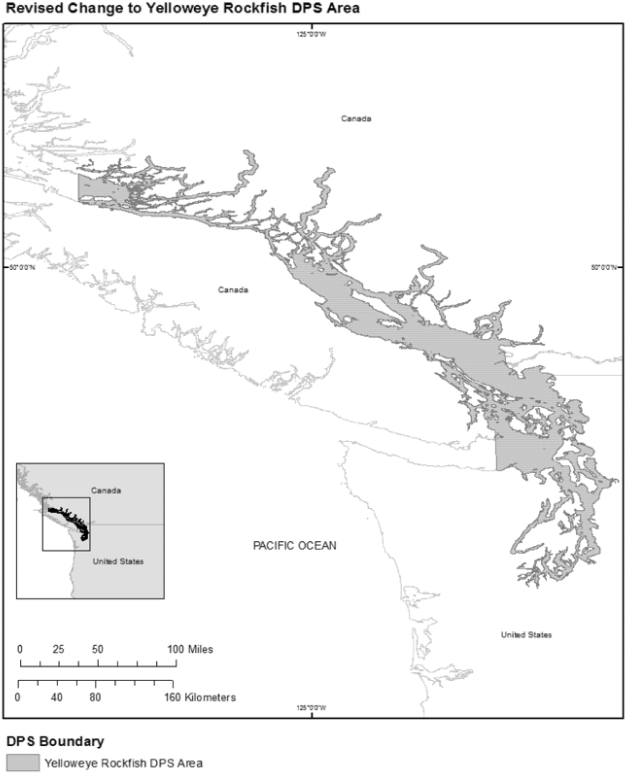

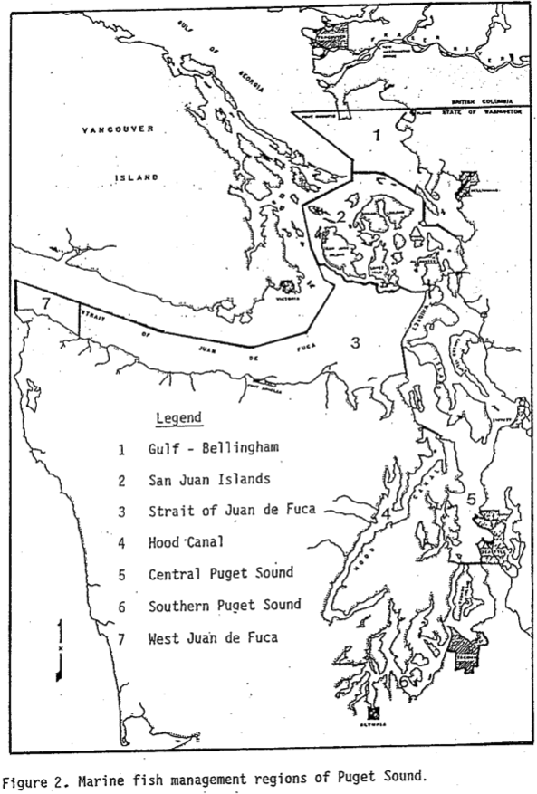

Commercial catch reporting areas for this time period; note how region 3 is only partially in the DPS

## Commercial Data: 1970-2003

### Catch Scenarios

- Yelloweye (non-HC) and Bocaccio:
  - High catch: All catch from the Strait of Juan de Fuca is included.
  - Medium catch: 50% of the catch from the Strait of Juan de Fuca is included.
  - Low catch: No catch from the Strait of Juan de Fuca is included.
- Likely an underestimate of uncertainty (e.g. in catch compositions), but because of summarized format of data provided it is difficult to parse apart scenarios

## Commercial Data: 1955-1969

### Overview

- Data from Yellow Book (Green Book); origins are a bit fuzzy but it’s generally accepted that this is the best source of commercial data statistics for this time period
- Market categories listed for this time period: “general rockfish”, “red snapper”, and “black rockfish”
  - Yelloweye catches for this time period are taken to be the “red snapper” category; unknown what proportion of this catch is actually yelloweye vs. other species (e.g. vermilion and canary), and if there are some yelloweye in the “general rockfish” category
- Bocaccio catch estimated by prorating the “general rockfish” category by gear and region based on the the 1970-1987 species composition estimates from Schmitt et al. 1991

## Commercial Data: 1955-1969

### Catch Scenarios

- Yelloweye (non-HC):
  - High catch: All “red snapper” catch from the Strait of Juan de Fuca is included.
  - Medium catch: 50% of the “red snapper” catch from the Strait of Juan de Fuca is included.
  - Low catch: No “red snapper” catch from the Strait of Juan de Fuca is included.
- Note: For the time period 1955-1969, no effort is recorded for gear types that caught Bocaccio in the Strait of Juan de Fuca and thus the catch of Bocaccio will not be affected by how much of the Strait of Juan de Fuca catch is included in the catch estimates.

## Commercial Data: 1935-1954

### Overview

- The Yellow Book data does not have any region-specific information for this time period, but there are catches by gear type
  - Yellow Book also does not have any catch data from 1933-1942
- The Bound Volumes do have region-specific information, (necessary to split Hood Canal from the rest of the catch)
- Bound Volumes data used for this time period
  - Note: Data from the Bound Volumes has never been formally QC’d; however, landings are comparable to Yellow Book values (see next slide)
- Catch composition data used is from species composition from 1970-1987, by gear and by region

## Commercial Data 1935-1954

### Bound Volumes vs. Yellow Book

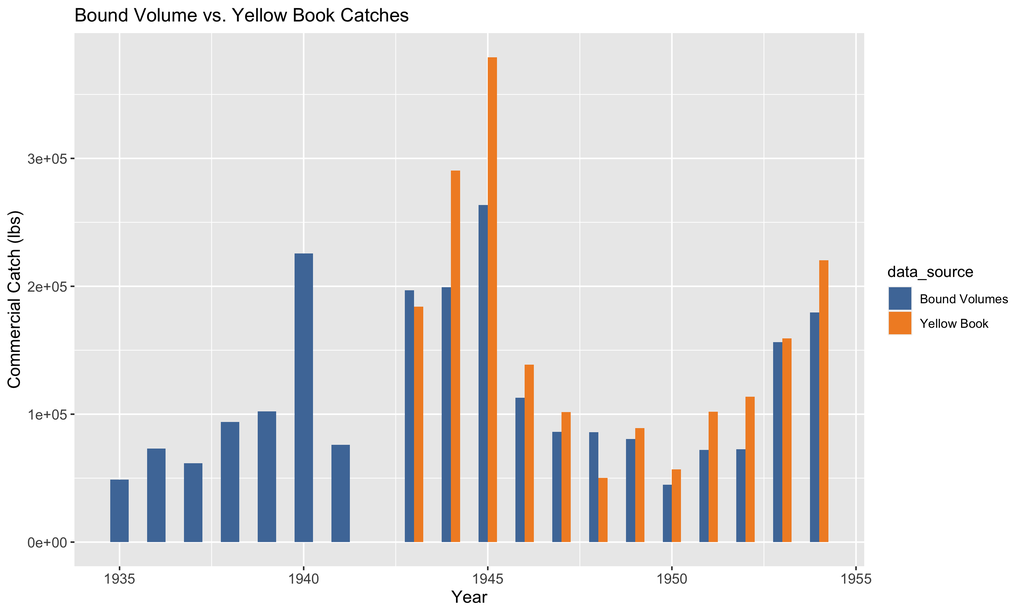

## Commercial Data 1935-1954

### Catch Scenarios

- Yelloweye and Bocaccio:
  - High catch: All catch from the Strait of Juan de Fuca is included.
  - Medium catch: 50% of the catch from the Strait of Juan de Fuca is included.
  - Low catch: No catch from the Strait of Juan de Fuca is included.

## Commercial Data 1921-1933

### Overview

- Catches from the Yellow Book
- Catches by gear type but not by region
- Total rockfish catch prorated to species using 1970-1987 species compositions by gear type and region
- Effort by region estimated roughly from Bound Volume effort distribution by region for following time period

## Commercial Data 1921-1933

### Effort Estimates by Region

| Region | Percentage of Effort |
| --- | --- |
| Central Puget Sound | 35% |
| Gulf - Bellingham | 15% |
| Hood Canal | 5% |
| San Juan Islands | 10% |
| Southern Puget Sound | 30% |
| Strait of Juan de Fuca | 5% |

## Commercial Data 1921-1933

### Catch Scenarios

This time period has a huge amount of uncertainty, but also has low catches and thus the different catch scenarios are unlikely to make much of a difference to estimates of initial stock size.

- Yelloweye and Bocaccio:
  - High catch: Double the prorated catch (2x estimates).
  - Medium catch: The prorated catch (1x estimates).
  - Low catch: Half of the prorated catch (0.5x estimates).

## Commercial Data

### Yelloweye (non-HC) Catch Scenarios

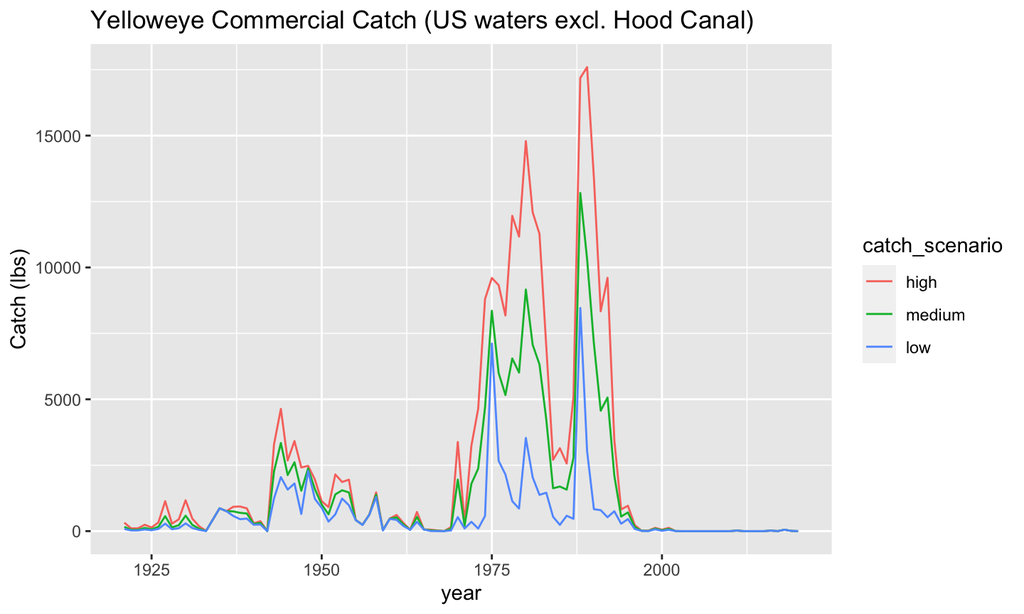

## Commercial Data

### Yelloweye (HC) Catch Scenarios

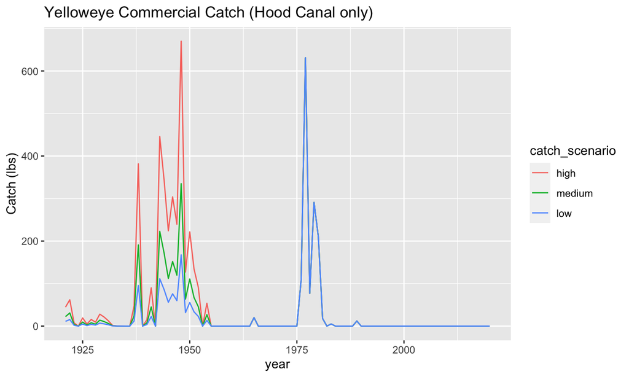

## Commercial Data

### Bocaccio Catch Scenarios

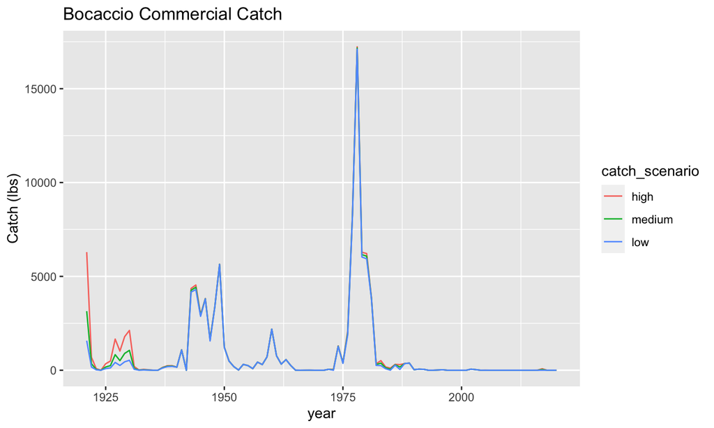

## Recreational Catch Reconstruction

## Recreational length data

- Potential sources of bias in this data? e.g. against small fish (discarded/released) or regional biases
- Data source? From Greg Bargmann’s archived files (likely Puget Sound sport interview data)

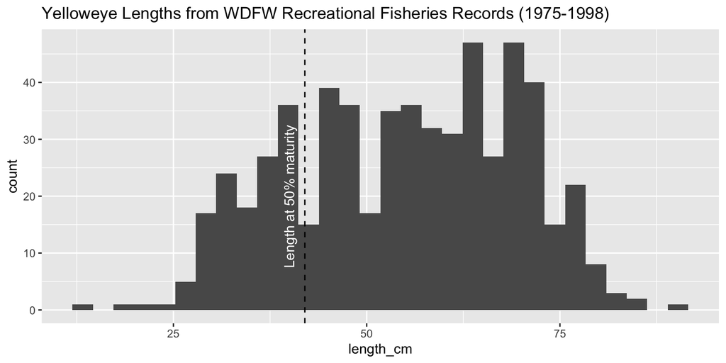

## Recreational Data

### Weight Conversions

- Recreational catches in numbers of fish and were be converted to weights for inclusion in model
- Same weight per individual used for each time period:
  - Yelloweye: 2.3 kg (5.07 lbs) mean weight; from Wildermuth 1983, based on mean weight (N = 124) from 1981, data collected by MRFSS samplers in “the marine waters of Washington”
  - Bocaccio: 4.08 kg (8.99 lbs) mean weight; source is “Old WDW19 program conversion” (value provided by Wayne Palsson)

## Recreational Data: 2003-2019

### Overview

- Estimates are from WDFW creel survey
  - Creel survey yields estimate and variance
- For rare species (like bocaccio and yelloweye), variance in estimates is very high
- Recreational catch is very low (retention of yelloweye banned in 2002, bocaccio are extremely rare)
- Statistics for both fish that were harvested and those that were released; how do we address the question of rockfish dying after release from barotrauma?
  - Hochhalter and Reed (2011) estimated almost 99% survival of yelloweye rockfish released at depth, but only about 22% of yelloweye rockfish released at the surface

## Recreational Data: 2003-2019

### Catch Scenarios

- Yelloweye and Bocaccio:
  - High catch: Creel estimate + one SD; 50% of estimated released rockfishes considered to be catch (died from barotrauma)
  - Medium catch: Creel estimate; 20% of estimated released rockfishes considered to be catch (died from barotrauma)
  - Low catch: Creel estimate - one SD; 5% of estimated released rockfishes considered to be catch (all released at depth, 95% survived - from Hannah et al. 2014, work done on yelloweye)

## Recreational Data: 1994-2002

### Overview

“Beginning in 1994, large–scale closures occurred for the recreational salmon fishery, preventing successful bottomfish catch and effort estimates in many areas of Puget Sound. When an area is closed to recreational salmon fishing, there is no numerator to divide by then effort or bottomfish catch rate, preventing any point estimate of effort or bottomfish catch. Consequently, bottomfish catch and effort estimates have been severely underestimated from 1994 to 2003.” (Palsson et al. 2009)

## Recreational Data: 1994-2002

### Catch Scenarios

We know that catch was underreported, but by how much? The estimates for this time period can be treated as a minimum estimate (the “low” scenario), but determining the other scenarios is more difficult.

- Yelloweye and Bocaccio:
  - High catch: Prorated estimate x 3.
  - Medium catch: Prorated estimate x 2.
  - Low catch: Prorated estimate x 1.

## Recreational Data: 1970-1993

### Overview

- Data from Wayne Palsson’s reports; comes from a combination of required catch records from salmon anglers and a dockside creel survey of hook-and-line anglers
  - Effort estimated by number of trips taken by salmon anglers (recreational fishery much better documented); this effort is then multiplied by estimates of bottomfish catch by anglers derived from the creel survey data
- Currently, there are no catch scenarios for this time period, as catches were already been estimated and prorated to species level for previous analyses.

## Recreational Data: 1965-1969

### Overview

- Tables from separate reports by Buckley, Sattherwhaite, and Bargmann.
- Catch compositions are from six technicians sampling the recreational salmon fishery, effort from the salmon fishery
- Noted that most bottomfish caught were discarded/released and thus not represented in these landings statistics:
  - “At present, the majority of Washington’s sport anglers consider most bottomfish as “scrap fish” and the ratio of the number retained in the harvest to the number actually caught appears extremely low in all areas.” (Buckley 1965)

## Recreational Data: 1938-1942

### Overview

- “Approximately 60% of the resorts reported regularly on a purely voluntary basis… It should be noted that all individual catches brought in to any given resort cannot be recorded by the manager. For that reason the catch statistics given below can be assumed to constitute only a very conservative record of the number of fish caught by recreational fishermen fishing from the various resorts.”
- “In estimating the total sports catch of any species for 1940, allowance must be made for (a) 43% of known boathouses not reporting during the eight-months period above, (b) four additional months to complete the year, and (c) catches made by persons not using boathouse facilities.”

## Recreational Data: 1938-1942

### Overview

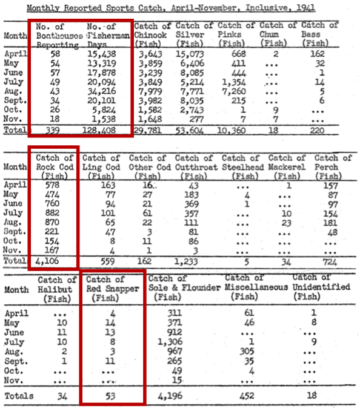

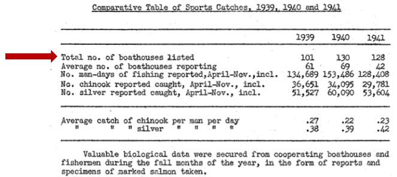

- Voluntary reporting by boathouses -> low reporting rates -> prorate to total boathouses
- Missing data for several months -> used mean catches from November for missing winter months
- Low confidence in species IDs; no way of knowing how many boathouses separated “red snapper” from “rock cod”
- Does not include private boat owners
- No distribution of boathouses

## Recreational Data: 1938-1942

### Estimating Total Effort

1949 WDFW Annual Bulletin:

“Surveys of the number fishermen using Puget Sound have been made by the department since 1938 but never at such scale as in 1949 when evaluation of **private fishing parties** was attempted along with the usual boathouse count… Boat counts in the sports fishing areas showed an average of about 30 private craft for every 100 rented boats during the busiest part of the 1949 season. The average in the winter months, from November through February, was about 7 for every 100.”

## Recreational Data: 1938-1942

### Estimating Total Effort

- Number of private boats estimated and added to boathouse estimates for 1938-1942 (also 1943-1948)
  - Exponential growth from Feb-August, exponential decay from August-November

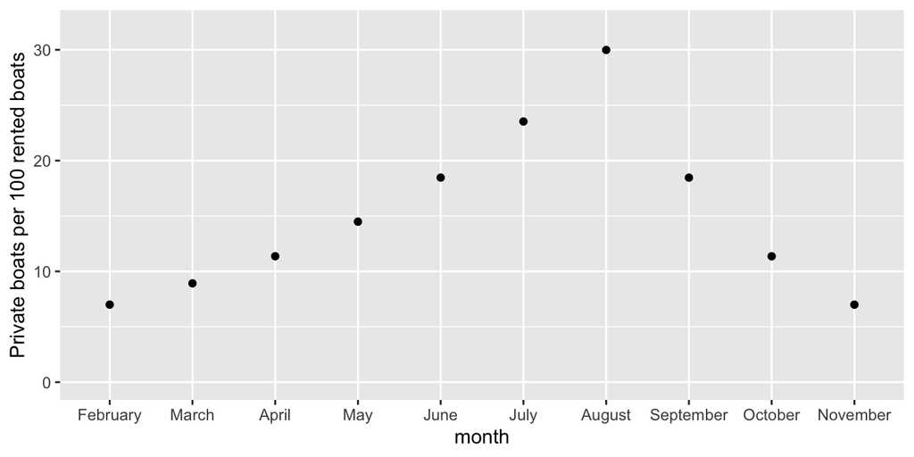

## Recreational Data: 1938-1942

### Catch Scenarios

- Yelloweye:
  - High catch scenario: In years where “red snapper” is listed, 2% of the other rockfish catch is red snapper. In years where no red snapper is listed (1938 and 1939), 4% of the rockfish catch is red snapper.
  - Medium catch scenario: In years where “red snapper” is listed, 1% of the other rockfish catch is red snapper. In years where no red snapper is listed (1938 and 1939), 2% of the rockfish catch is red snapper.
  - Low catch scenario: In years where “red snapper” is listed, it is the only yelloweye catch. In years where no red snapper is listed (1938 and 1939), prorate catch based on mean proportion of total rockfishes that are “red snapper” from the years 1940-42.

## Recreational Data: 1938-1942

### Catch Scenarios

- Bocaccio:
  - High catch scenario: 2% of the rockfish catch is bocaccio
  - Medium catch scenario: 1% of the rockfish catch is bocaccio
  - Low catch scenario: No bocaccio were caught (0%)

## Recreational Data: 1943-1964

### Overview

- No estimates of recreational bottomfish catch for this time period
- However, there are sporadic estimates of effort from the salmon fishery
  - Can be used in a similar fashion to how salmon effort was used in more recent estimates of recreational bottomfish catch

## Recreational Data: 1943-1964

### Effort

- Effort from WDF Annual Bulletin; not reported every year
- Interpolated missing values using linear interpolation

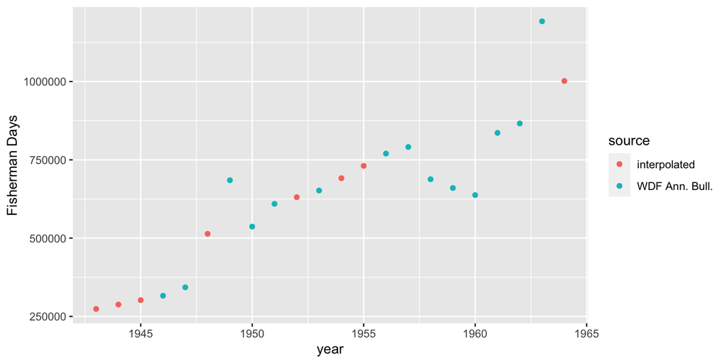

## Recreational Data: 1943-1964

### Where were boathouses located?

[figure not shown]

## Recreational Data: 1943-1964

### Where were boathouses located?

| Region | Boathouses | Percent |
| --- | --- | --- |
| Strait of Juan de Fuca | 5 | 4% |
| San Juan Islands | 13 | 10% |
| Deception Pass, Hope Islands, Skagit Bay, Ports Susan and Gardner | 25 | 18% |
| Admiralty Inlet | 30 | 22% |
| Seattle/Bremerton | 20 | 15% |
| South Sound | 20 | 15% |
| Hood Canal | 22 | 16% |

## Recreational Data: 1943-1964

### Estimating bottomfish catches

- CPUE of rockfish by salmon angler day estimated as mean CPUE from 1938-1942 (0.04 RF/salmon angler day); this value is similar to CPUE of incidental bottomfish catch in Buckley reports (1965-1967)
- Species composition data from 1965-67 Buckley estimates (closest estimates of composition, temporally); different observed species compositions used in different catch scenarios
- Area of catch apportioned by map of boathouses with aforementioned proportions

## Recreational Data: 1943-1964

### Catch scenarios

- Yelloweye and Bocaccio:
  - High catch scenario: Use max annual Buckley (1965-1967) catch proportions
    - Tweaked slightly for Hood Canal, as the max proportion of total rockfish as yelloweye was 22% in 1965; instead 1.5x the mean yelloweye proportion was used for the high scenario
  - Medium catch scenario: Use mean Buckley (1965-1967) catch proportions
  - Low catch scenario: Use min annual Buckley (1965-1967) catch proportions

## Recreational Data

### Yelloweye (non-HC) Catch Scenarios

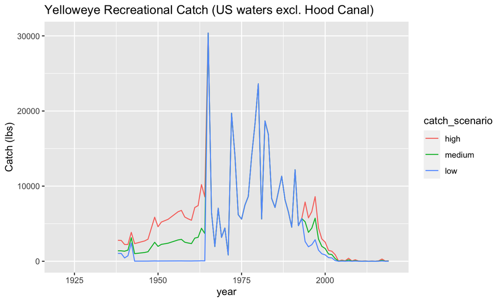

## Recreational Data

### Yelloweye (HC) Catch Scenarios

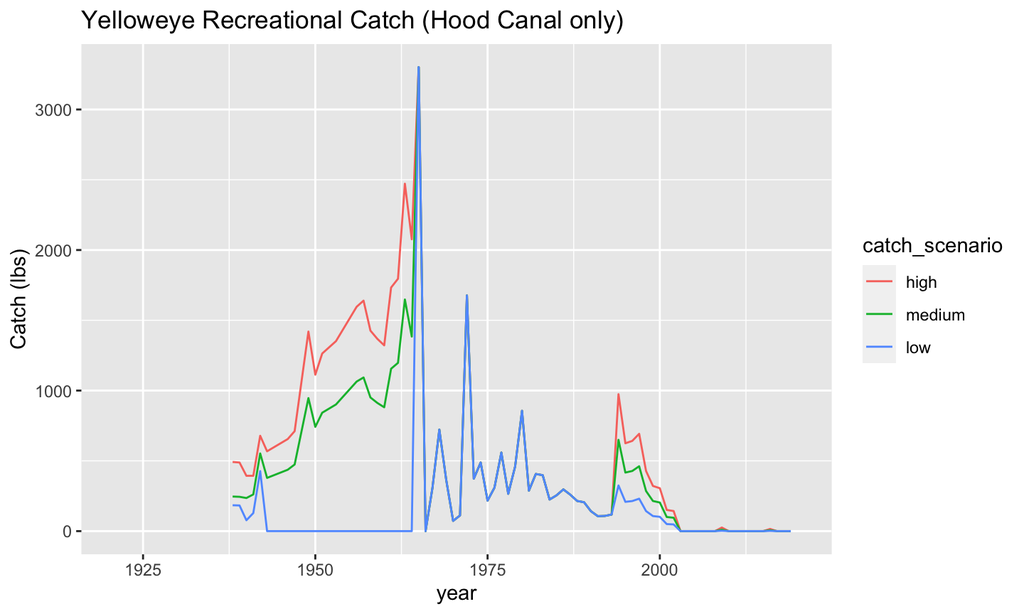

## Recreational Data

### Bocaccio Catch Scenarios

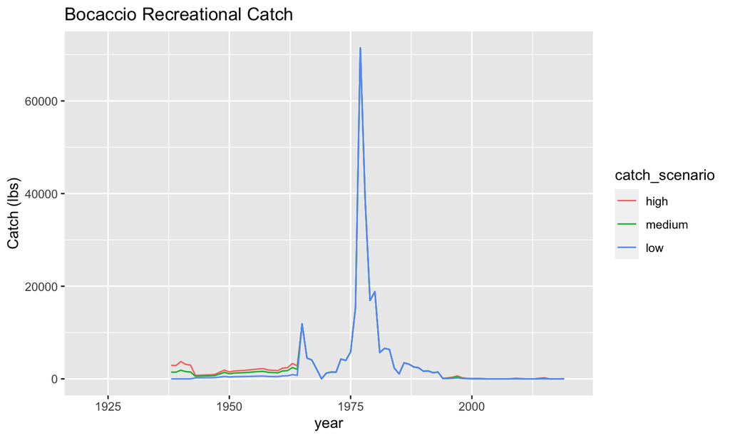

## Total catches

## Commercial + Recreational Data

### Yelloweye (non-HC) Catch Scenarios

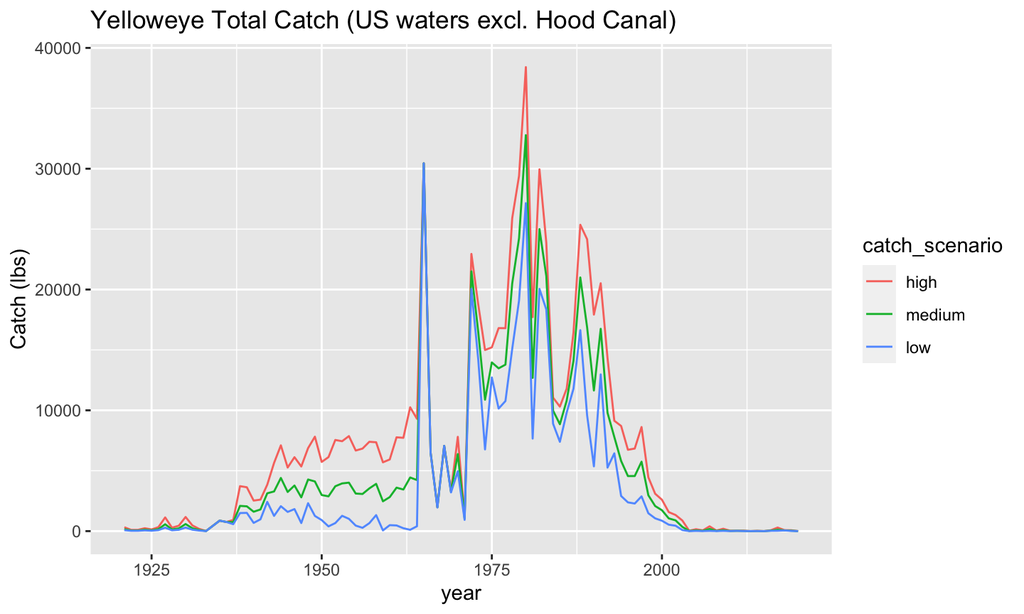

## Commercial + Recreational Data

### Yelloweye (HC) Catch Scenarios

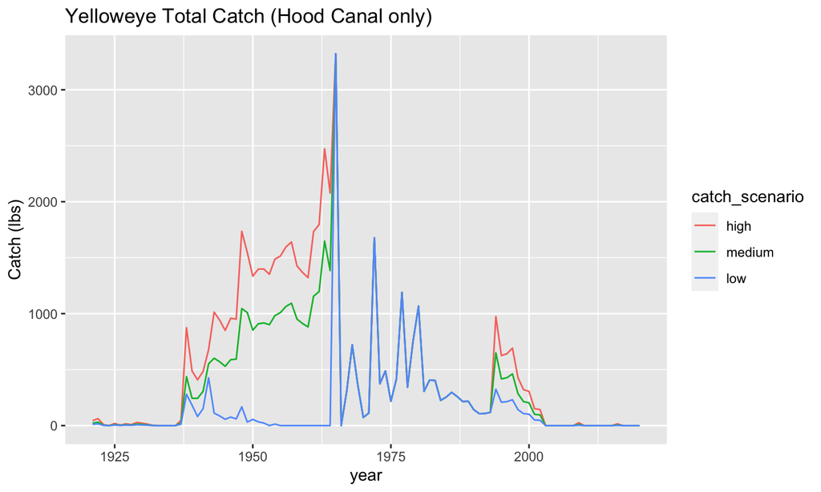

## Commercial + Recreational Data

### Bocaccio Catch Scenarios

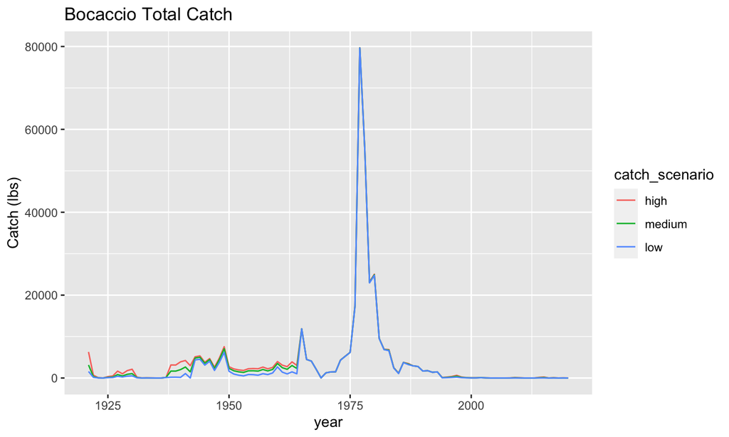